# Final Exam -- Math 252 (Hellen)

## Final Exam -- Math 252 (Hellen)

#### Question

1. Suppose $p(A) = 0.35$, $p(B) = 0.4$ and $p(A \cap B) = 0.25$.

   Answer the following questions. Record your answers here in Moodle, but be sure to **also show your work on your test paper.**
   1. What is $p(A \cup B)$?
   2. What is $p(A \mid B)$?
   3. What is $p(B \mid A)$?
   4. Which is true: Events A and B are **independent**. / Events A and B are **not independent**
   5. Which is true: Events A and B are **mutually exclusive**. / Events A and B are **not mutually exclusive**.

#### Question

2. Enter the numerical value of $\binom{13}{4} = C(13, 4)$ in the blank below and **show how to compute this value without using a calculator** on your paper.

#### Question

3. Consider strings of length 10 over the 3-letter alphabet $\{x, y, z\}$.

   Answer the following questions by putting integer values in the blanks below. **Show your work on your paper.**
   1. How many such strings are there?
   2. How many of these strings have exactly 4 x’s?
   3. How many of these strings have exactly 4 x’s and exactly 2 y’s?
   4. How many of these strings have exactly 4 x’s or exactly 2 y’s?

#### Question

4. A patient with symptoms comes to the doctors office. The symptoms are fairly non-descript, but the doctor thinks there is a 20% chance that the patient has a serious condition. So she orders a test for the patient. Based on studies, it is believed that
   - The test correctly identfies 87% of people who have the serious condition.
   - The test correctly identfies 90% of people who do not have the serious condition.

   If the test comes back positive (indicating the patient has the condition), what is the probability that the patient actually has the condition?

   Put your answer in the box below and show your work on your paper.

#### Question

5. Estimates for the proportion of people who have COVID-19 in a given community vary from place to place. But let’s suppose that in some community 4% of people are infected.

   If a random group of 20 people gather, what is the probability that at least one of them is infected?

#### Question

6. Let $X$ be a random variable that takes on values 2, 3, or 4. $p(X = 2) = 0.2$, and $p(X = 3) = 0.1$.

   Answer the questions below and show your work on your paper.
   1. What is $p(X = 4)$?
   2. What is the expected value of $X$?

#### Question

7. Answer the following questions about the graph below.

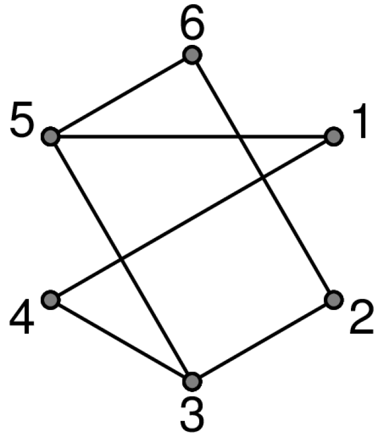

   Answer the following questions on your paper.
   1. What is an Euler circuit?
   2. Does the graph have an Euler circuit? How do you know?
   3. Does the graph have an Euler path that is not a circuit? How do you know?
   4. Is the graph planar? How do you know?
   5. Is the graph bipartite? How do you know?
   6. What is the degree of vertex 6?

#### Question

8. **How many isomorphisms** are there between the following two graphs? Enter the number in box below and provide an explanation on your paper.

   (Enter 0 if the graphs are not isomorphic. If you do not know exactly how many there are, tell me as much as you know about how many there are. Examples: There is at least 1; there are at most 3, etc.)

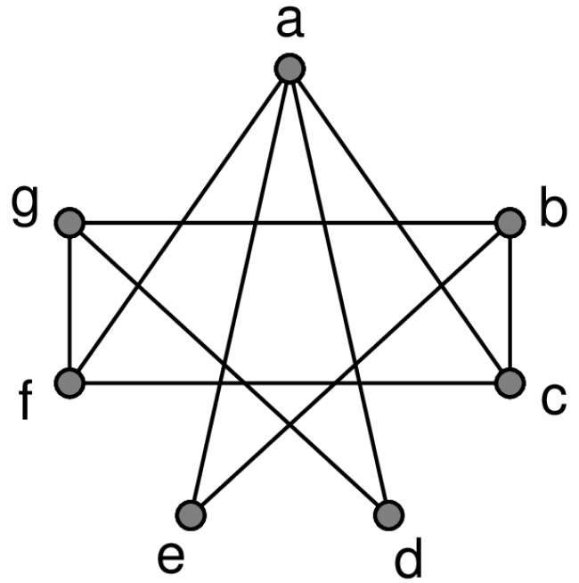

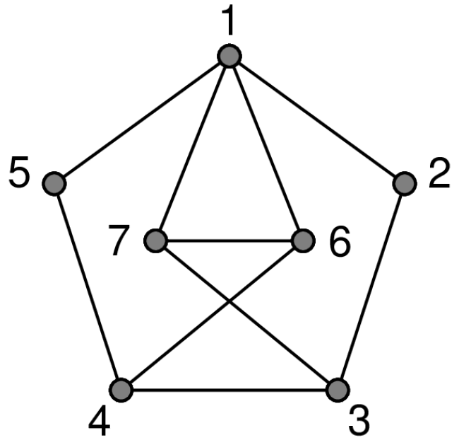

#### Question

9. Answer parts b and c on your paper. Label them clearly.
   1. If a graph has 6 and each vertex has degree 4, how many edges will it have?
   2. Explain why it is impossible to draw a simple graph with 7 vertices, each of degree 3.
   3. Give an example of a graph that is **not a planar graph** and **explain** how you know it is not planar. **Do not use Kuratowski’s Theorem.**

#### Question

10. What is the output of the following python code?

    ```
    import re as re
    re.findall(r'b+a*[cd]*', 'abcdabcddcbaabbccddccbbaa')
    ```

#### Question

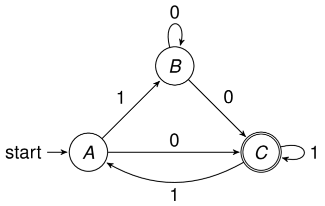

    Indicate which strings in a-f are in $L(N)$. (Indicate all that apply.)

    On your paper, answer these two questions:
    7. Design a **DFA** that accepts the same language as $N$ using a **general method** that works for all NFAs. You may use a transition table or a state diagram, but be sure to indicate any starting and accepting states.
    8. Construct a **regular grammar** for this language using a **general method** that works for all NFAs. Call your start symbol $S$.
    1. $101 \in L(N)$
    2. $0011 \in L(N)$
    3. $1001 \in L(N)$
    4. $0100 \in L(N)$
    5. $0101 \in L(N)$
    6. $01100 \in L(N)$

#### Question

12. Let $L$ be the langauge consisting of all binary strings that end with at least two 0’s followed by at least one 1. Examples: $10011 \in L$, $0010 \not \in L$, $01011 \not \in L$.

    Answer the following questions on your paper. (You can ignore the Moodle entry area.)
    1. Write a **regular expression** for $L$.
    2. Construct a **DFA** that recognizes $L$. (You do not need to use any particular method.)

#### Question

13. Answer **ONE** of the following (your choice) on your paper:
    1. Give an example of a language that is **not regular**, and explain how you know the language is not regular.
    2. Give an example of a language that is **not Turing computable** and explain how you know the language is not Turing computable.

    You can ignore the Moodle entry area.

#### Question

14. Below is the instruction set for a Turing machine $M$ with start state `0` and accepting state `halt-accept`. In each row, the columns are in the order current state, current symbol, new symbol, direction, new state.

    ```
    ; Machine starts in state 0.

    0  a   x   R   1
    0  b   b   R   0
    0  x   x   R   2

    1  a   a   R   2
    1  b   x   L   1
    1  x   x   R   3

    2  a   x   R   halt-reject
    2  b   b   L   3
    2  x   x   R   2

    3  a   a   R   halt-accept
    3  b   b   L   3
    3  x   x   R   2
    ```

    Fill out the table below. In the first two columns record the contents of the tape after the machine takes 5 steps. (If it halts before then, write down the tape contents and state when it halts.) In the last column type the word “accept” or the word “reject” (all lower case).

    | input string | tape after 5 steps | state after 5 steps | accept or reject |
    | --- | --- | --- | --- |
    | baba |  |  |  |
    | baab |  |  |  |
    | abba |  |  |  |